# ST 558 - Project 1 - Christine Marie Heubusch

Christine Marie Heubusch

June 12, 2020

# Understanding JSON Data

## What is JSON data?

[JavaScript Object Notation (JSON)](https://www.json.org/json-en.html) is a format of storing data that is “lightweight” (that is, tends to be a small file size) and integrates well with most programming languages, though it is technically a subset of JavaScript. These properties make it a favorite format for application programming interfaces (APIs) and is often used to [“serialize and transfer data over a network connection”](https://www.w3resource.com/JSON/introduction.php). In JSON, [data can be stored in a variety of different ways](https://www.youtube.com/watch?v=iiADhChRriM&list=TLPQMTAwNjIwMjBzt1zaeUU28g&index=2), including strings, numbers, booleans (with the true/false operators), arrays, and null. While objects are wrapped with a left and right curly brace ({}), arrays are enclosed in brackets ([]). Objects contain [key-value pairs](https://www.w3schools.com/js/js_json_objects.asp), with the key being a string, a value being one of the aformed JSON data types, and a colon separating the two; each key-value pair is separated with a comma. Values may be nested in a JSON data object, which makes it both convenient and easy to read.

## Packages Used for Reading JSON Data

Three R packages can be utilized for working with JSON data:

- `rjson`
- `RJSONIO`
- `jsonlite`

All three packages offer options for converting to/from JSON. `RJSONIO` was originally introduced as a [faster alternative](https://www.rdocumentation.org/packages/RJSONIO/versions/1.3-1.4) to `rjson`, given concerns about the latter’s slower speeds, though there are some indications that `rjson` may now actaully be faster in certain circumstances. I have selected `jsonlite` - which debuted in 2014 and originally [started as a branch of `RJSONIO`](https://cran.r-project.org/web/packages/jsonlite/index.html#:~:text=In%20addition%20to%20converting%20JSON,data%20in%20systems%20and%20applications.) - as my package of choice. Documentation on the package is extensive, as evidenced by the package’s thorough [vignette](https://cran.r-project.org/web/packages/jsonlite/jsonlite.pdf); and a wide variety of useful functions and options are within. Interestingly, only `RJSONIO` and `jsonlite` [give control over vector simplification](https://rstudio-pubs-static.s3.amazonaws.com/31702_9c22e3d1a0c44968a4a1f9656f1800ab.html), an important consideration when parsing JSON data.

# Contacting the NHL API

When I first tried converting the data from JSON, *“data.”* appeared at the beginning of each column name; ostensibly, this points to the object within which the array of data was stored in JSON. However, thinking this a bit cumbersome for usage in later code, per Subhankar’s recommendation, I played around with using [`str_remove`](https://www.rdocumentation.org/packages/stringr/versions/1.4.0/topics/str_remove) to remove the string, and found it to be useful for keeping the column names short and more enjoyable to work with.

## Creating a Function for Accessing Franchise Data

```r
api_function_franchise <- function(x) {
  base_url <- "https://records.nhl.com/site/api"
  x <- "franchise"
  full_url <- paste0(base_url, "/", x)
  franchise_get <- GET(full_url)
  franchise_txt <- content(franchise_get, "text")
  franchise_json <- fromJSON(franchise_txt, flatten=TRUE, simplifyDataFrame=TRUE)
  franchise_df <- as.data.frame(franchise_json)
  colnames(franchise_df) <- str_remove(colnames(franchise_df), "data.")
  return(franchise_df)
}
franchise_data <- api_function_franchise(x)
#view(franchise_data)
head(franchise_data)
```

```
##   id firstSeasonId lastSeasonId mostRecentTeamId teamCommonName teamPlaceName
## 1  1      19171918           NA                8      Canadiens      Montréal
## 2  2      19171918     19171918               41      Wanderers      Montreal
## 3  3      19171918     19341935               45         Eagles     St. Louis
## 4  4      19191920     19241925               37         Tigers      Hamilton
## 5  5      19171918           NA               10    Maple Leafs       Toronto
## 6  6      19241925           NA                6         Bruins        Boston
##   total
## 1    38
## 2    38
## 3    38
## 4    38
## 5    38
## 6    38
```

## Creating a Function for Accessing Franchise Team Totals

```r
api_function_totals <- function(x) {
  base_url <- "https://records.nhl.com/site/api"
  x <- "franchise-team-totals"
  full_url <- paste0(base_url, "/", x)
  team_totals_get <- GET(full_url)
  team_totals_txt <- content(team_totals_get, "text")
  team_totals_json <- fromJSON(team_totals_txt, flatten=TRUE)
  team_totals_df <- as.data.frame(team_totals_json)
  colnames(team_totals_df) <- str_remove(colnames(team_totals_df), "data.")
  return(team_totals_df)
}
team_totals_data <- api_function_totals(x)
#view(team_totals_data)
head(team_totals_data)
```

```
##   id activeFranchise firstSeasonId franchiseId gameTypeId gamesPlayed
## 1  1               1      19821983          23          2        2937
## 2  2               1      19821983          23          3         257
## 3  3               1      19721973          22          2        3732
## 4  4               1      19721973          22          3         272
## 5  5               1      19261927          10          2        6504
## 6  6               1      19261927          10          3         515
##   goalsAgainst goalsFor homeLosses homeOvertimeLosses homeTies homeWins
## 1         8708     8647        507                 82       96      783
## 2          634      697         53                  0       NA       74
## 3        11779    11889        674                 81      170      942
## 4          806      869         46                  1       NA       84
## 5        19863    19864       1132                 73      448     1600
## 6         1436     1400        103                  0        1      137
##   lastSeasonId losses overtimeLosses penaltyMinutes pointPctg points roadLosses
```

[output cut: 20 more lines]

## Creating a Function for Accessing Season Records

```r
api_function_season <- function(franchiseID) {
  base_url <- "https://records.nhl.com/site/api"
  full_url <- paste0(base_url, "/", "franchise-season-records?cayenneExp=franchiseId=", franchiseID)
  season_get <- GET(full_url)
  season_txt <- content(season_get, "text")
  season_json <- fromJSON(season_txt, flatten=TRUE)
  season_df <- as.data.frame(season_json)
  colnames(season_df) <- str_remove(colnames(season_df), "data.")
  return(season_df)
}
seasonCaps <- api_function_season(24) #Testing the function with Washington Capitals data, since I'm originally from the DC area!
#view(seasonCaps)
```

```r
api_function_goalie <- function(franchiseID) {
  base_url <- "https://records.nhl.com/site/api"
  full_url <- paste0(base_url, "/", "franchise-season-records?cayenneExp=franchiseId=", franchiseID)
  goalie_get <- GET(full_url)
  goalie_txt <- content(goalie_get, "text")
  goalie_json <- fromJSON(goalie_txt, flatten=TRUE)
  goalie_df <- as.data.frame(goalie_json)
  colnames(goalie_df) <- str_remove(colnames(goalie_df), "data.")
  return(goalie_df)
}
goalieCanes<- api_function_goalie(26) #Testing the function with Carolina Hurricanes data, to honor my new home.
#view(goalieCanes)
```

```r
api_function_skater <- function(franchiseID) {
  base_url <- "https://records.nhl.com/site/api"
  full_url <- paste0(base_url, "/", "franchise-season-records?cayenneExp=franchiseId=", franchiseID)
  skater_get <- GET(full_url)
  skater_txt <- content(skater_get, "text")
  skater_json <- fromJSON(skater_txt, flatten=TRUE)
  skater_df <- as.data.frame(skater_json)
  colnames(skater_df) <- str_remove(colnames(skater_df), "data.")
  return(skater_df)
}
skaterPenguins <- api_function_skater(17) #Testing the function - sure, I suppose I'll look at some Penguins data too!
#view(skaterPenguins)
```

# Exploratory Data Analysis

## Is a Team With More Recorded Shutouts More Likely to Still be an Active Franchise?

In a [shutout game](https://en.wikipedia.org/wiki/Shutout), a hockey team’s defense manages to prevent the other team from scoring any points throughout the entirety of the game - surely, a sign of strong performance! To begin, I decided to created a categorical variable called **shutoutRange**, creating ranges for total number of shutouts and using `ifelse` to assign each value to the appropriate level of the new variable. I then created a contingency table to get a quick glimpse of how many active (and inactive) franchises fell within each category. Not too surprisingly, none of the teams that had a history of over a 100 shutouts were inactive. To visualize this data, I created a barplot, filling the bars with color based upon whether or not the franchise is active.

```r
team_totals_data <- mutate(team_totals_data, shutoutRange =
                             ifelse(shutouts %in% 0:50, "0-50",
                                ifelse(shutouts %in% 51:100, "51-100",
                                ifelse(shutouts %in% 101:150, "101-150",
                                ifelse(shutouts >150, "151+", "")))))
team_totals_data$shutoutRange <- factor(team_totals_data$shutoutRange, levels=c("0-50", "51-100", "101-150","151+")) #Changed these values to factors so that they could be easily ordered for the barplot below.
```

```r
shutoutTable <- table(team_totals_data$activeFranchise, team_totals_data$shutoutRange)
kable(shutoutTable, caption="Table of Active or Non-Active Franchise vs. Total Number of Shutouts")
```

Table of Active or Non-Active Franchise vs. Total Number of Shutouts

|  | 0-50 | 51-100 | 101-150 | 151+ |
| --- | --- | --- | --- | --- |
| 0 | 15 | 3 | 0 | 0 |
| 1 | 54 | 4 | 12 | 16 |

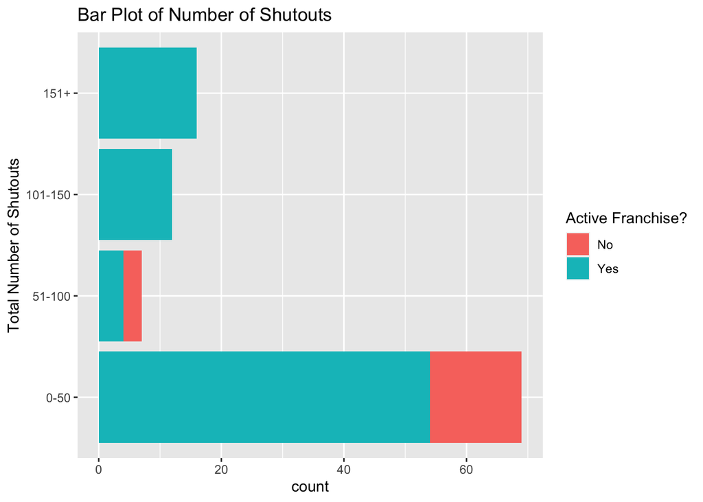

```r
shutoutGraph<- ggplot(data=team_totals_data, aes(x=shutoutRange))
shutoutGraph + geom_bar(aes(fill=as.factor(activeFranchise))) +
  labs(x="Total Number of Shutouts", title="Bar Plot of Number of Shutouts") +
  scale_fill_discrete(name="Active Franchise?", labels=c("No","Yes")) +
  coord_flip()
```

## Are Teams more Likely to Win at Home than Away?

*For this purposes of this variable, I did not include ties.*

```r
team_totals_data <- mutate(team_totals_data, roadWinLossRatio = roadWins / roadLosses)
team_totals_data <- mutate(team_totals_data, homeWinLossRatio = homeWins / homeLosses)

team_totals_data %>%
  select(teamName, roadWinLossRatio, homeWinLossRatio) %>%
  arrange(teamName) %>%
  head()
```

```
##            teamName roadWinLossRatio homeWinLossRatio
## 1     Anaheim Ducks        0.9743590        1.5000000
## 2     Anaheim Ducks        0.9114471        1.6158358
## 3   Arizona Coyotes        0.6718750        0.9629630
## 4    Atlanta Flames        0.6858974        1.5480769
## 5    Atlanta Flames        0.0000000        0.3333333
## 6 Atlanta Thrashers        0.6824034        0.8970588
```

```r
roadWLR <- summary(team_totals_data$roadWinLossRatio)
roadWLR
```

```
##    Min. 1st Qu.  Median    Mean 3rd Qu.    Max.
##  0.0000  0.4384  0.7130  0.6497  0.8788  1.2340
```

```r
homeWLR <- summary(team_totals_data$homeWinLossRatio)
homeWLR
```

```
##    Min. 1st Qu.  Median    Mean 3rd Qu.    Max.    NA's
##  0.0000  0.9069  1.3024  1.2541  1.5573  3.0000       1
```

Looking at the mean and median win-to-loss ratios for on the road (or “away”) and home, we see that both the home mean and median ratios are nearly double for home games - perhaps indicating that a team is more likely to win when it’s playing on its own ice. We can then look at boxplots of these ratios, as a visual representation of these summary statistics.

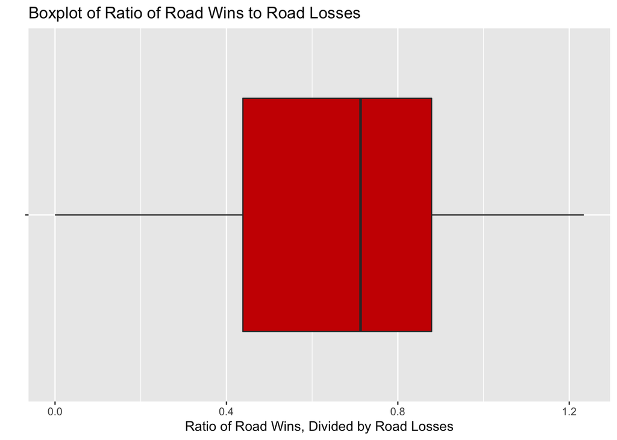

```r
penalty_plot <- ggplot(team_totals_data, aes(x=roadWinLossRatio,y=""))
penalty_plot +
  geom_boxplot(fill="#cc0000") +
  ggtitle("Boxplot of Ratio of Road Wins to Road Losses") +
  labs(x="Ratio of Road Wins, Divided by Road Losses", y="")
```

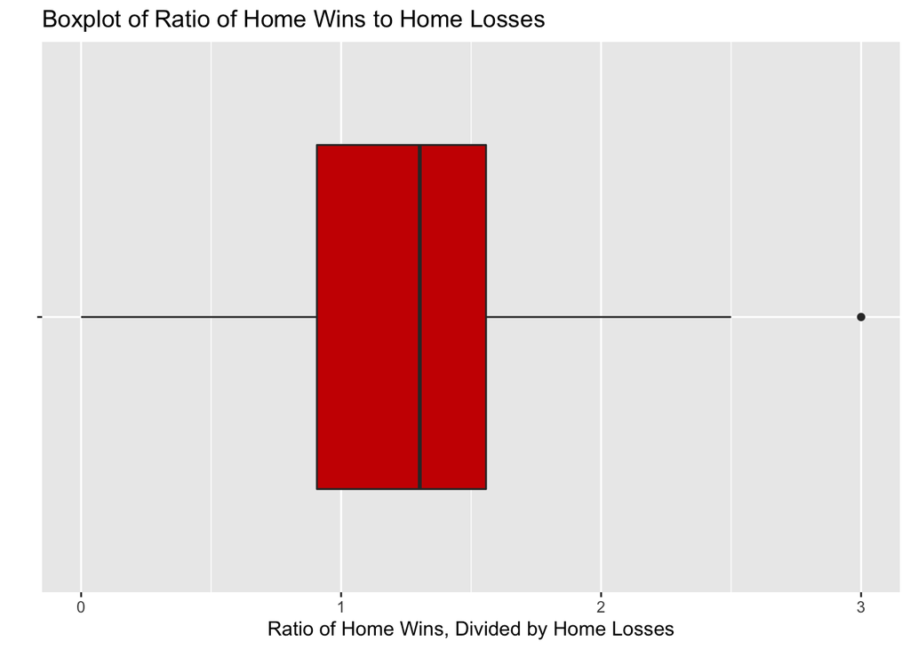

```r
penalty_plot <- ggplot(team_totals_data, aes(x=homeWinLossRatio,y=""))
penalty_plot +
  geom_boxplot(fill="#cc0000") +
  ggtitle("Boxplot of Ratio of Home Wins to Home Losses") +
  labs(x="Ratio of Home Wins, Divided by Home Losses", y="")
```

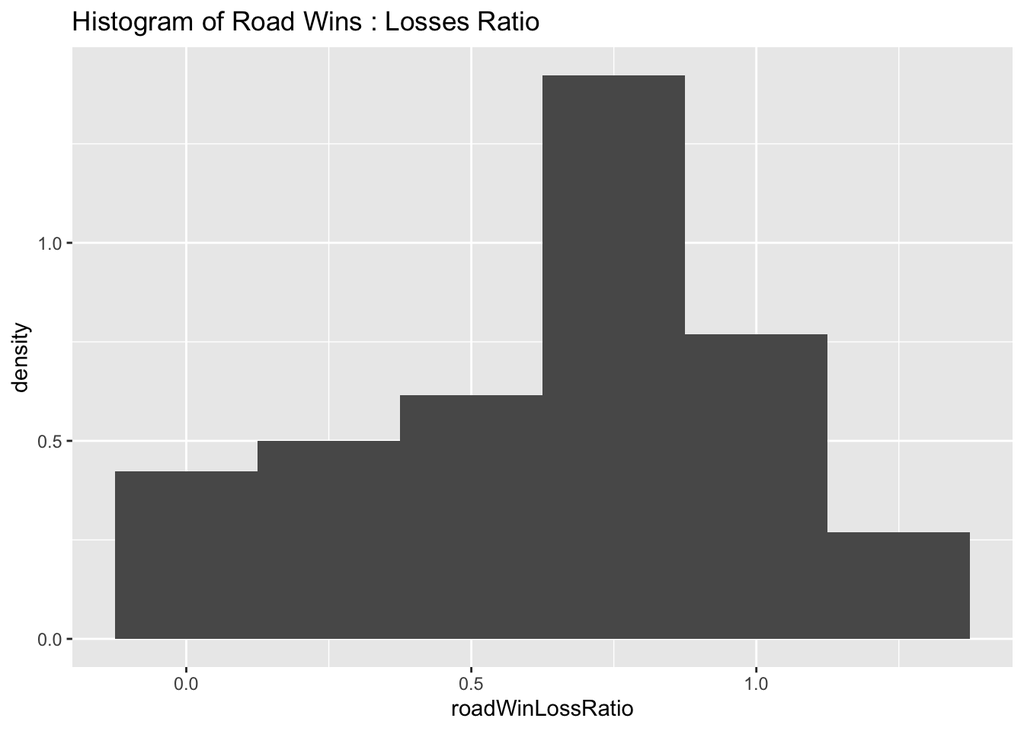

```r
roadWinsLossesHist <- ggplot(team_totals_data, aes(x=roadWinLossRatio))
roadWinsLossesHist +
  geom_histogram(aes(y=..density..), binwidth=0.25) +
  ggtitle("Histogram of Road Wins : Losses Ratio")
```

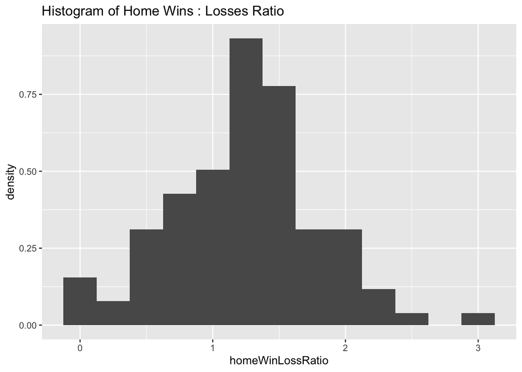

```r
homeWinsLossesHist <- ggplot(team_totals_data, aes(x=homeWinLossRatio))
homeWinsLossesHist +
  geom_histogram(aes(y=..density..), binwidth=0.25) +
  ggtitle("Histogram of Home Wins : Losses Ratio")
```

## Do Aggressive Teams Tend to Win More?

Do teams that spend more time in the penalty box tend to win more? To help explore this question, I created two new variables from the Franchise Team Totals dataset (that is, R object team_totals_data).

Here, I used the `mutate` function from the `dplyr` package to create a new variable called **penaltyGamesRatio** - the total number of minutes spent in the penalty box, divided by the total number of games played. This variable is intended to display the average amount of time per game a team’s players spend in penalty - perhaps a larger number is indicative of a more “aggressive” playing style.

```r
team_totals_data <- mutate(team_totals_data, penaltyGamesRatio = penaltyMinutes / gamesPlayed)

team_totals_data %>%
  arrange(desc(penaltyGamesRatio)) %>%
  select(teamName, penaltyGamesRatio) %>%
  head()
```

```
##               teamName penaltyGamesRatio
## 1     Quebec Nordiques          30.42500
## 2    Atlanta Thrashers          28.75000
## 3       Atlanta Flames          27.11765
## 4     Hartford Whalers          25.97959
## 5       Toronto Arenas          25.14286
## 6 Winnipeg Jets (1979)          24.93548
```

I then calculated an **overall** “win-to-loss” ratio, by dividing total number of wins by total number of losses. My hope here was to create a standardized measure, controlling for the amount of time that a team had been in operation, so that new teams and old teams could be compared equitably. Upon printing the first six rows of the data, we see that the Vegas Golden Knights - a team that just began in 2017 - has the highest win-to-loss ratio.

```r
team_totals_data <- mutate(team_totals_data, winLossRatio = wins / losses)
team_totals_data %>%
  select (teamName, winLossRatio) %>%
  arrange(desc(winLossRatio)) %>%
  head()
```

```
##               teamName winLossRatio
## 1 Vegas Golden Knights     1.662500
## 2      Edmonton Oilers     1.514286
## 3   Montréal Canadiens     1.512056
## 4         Dallas Stars     1.475661
## 5 Vegas Golden Knights     1.454545
## 6  Philadelphia Flyers     1.437369
```

I then created another variable: **MoreWinsOrLosses**, using `ifelse`. If a team won more than it lost (that is, its winLossRatio > 1), then the value of MoreWinsOrLosses was designated as “More Wins”. Otherwise, it was assigned a value of “More Losses”. *(For the purposes of this project, I designated the scenario of an equal number of wins and losses as “More Losses”.)*

```r
team_totals_data <- mutate(team_totals_data, moreWinsOrLosses = ifelse(winLossRatio > 1, "More Wins", "More Losses"))
team_totals_data %>%
  select(teamName, winLossRatio, moreWinsOrLosses) %>%
  arrange(teamName) %>%
  head(10)
```

```
##              teamName winLossRatio moreWinsOrLosses
## 1       Anaheim Ducks    1.2191781        More Wins
## 2       Anaheim Ducks    1.2101990        More Wins
## 3     Arizona Coyotes    0.8050847      More Losses
## 4      Atlanta Flames    1.0307692        More Wins
## 5      Atlanta Flames    0.1333333      More Losses
## 6   Atlanta Thrashers    0.7826087      More Losses
## 7   Atlanta Thrashers    0.0000000      More Losses
## 8       Boston Bruins    1.3439464        More Wins
## 9       Boston Bruins    0.9907407      More Losses
## 10 Brooklyn Americans    0.5517241      More Losses
```

```r
shutoutTable <- table(team_totals_data$activeFranchise, team_totals_data$shutoutRange)
kable(shutoutTable, caption="Table of Active or Non-Active Franchise vs. Total Number of Shutouts")
```

Table of Active or Non-Active Franchise vs. Total Number of Shutouts

|  | 0-50 | 51-100 | 101-150 | 151+ |
| --- | --- | --- | --- | --- |
| 0 | 15 | 3 | 0 | 0 |
| 1 | 54 | 4 | 12 | 16 |

```r
kable(table(team_totals_data$moreWinsOrLosses, team_totals_data$shutoutRange), caption="Contingency Table of More Wins or Losses and Shutout Range")
```

Contingency Table of More Wins or Losses and Shutout Range

|  | 0-50 | 51-100 | 101-150 | 151+ |
| --- | --- | --- | --- | --- |
| More Losses | 53 | 2 | 2 | 2 |
| More Wins | 16 | 5 | 10 | 14 |

Looking at the resulting boxplot *(below)*, we can see that the median amount of time spent in the penalty box by a “winning” team is greater than that of a “losing” team. Yet interestingly, the winning team range is much, much shorter than that of a losing team, and two losing teams prove to be outliers, with one team spending an average of *over 30 minutes a game* in the penalty box.

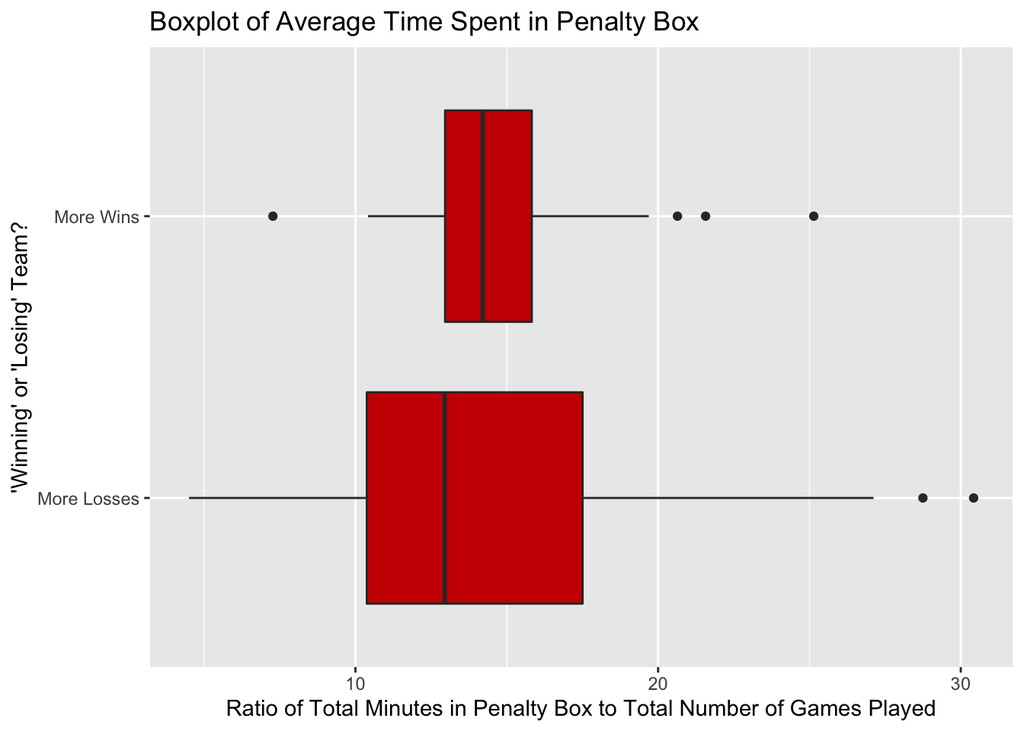

```r
penalty_plot <- ggplot(team_totals_data, aes(x=penaltyGamesRatio,y=moreWinsOrLosses))
penalty_plot +
  geom_boxplot(fill="#cc0000") +
  ggtitle("Boxplot of Average Time Spent in Penalty Box") +
  labs (x="Ratio of Total Minutes in Penalty Box to Total Number of Games Played", y="'Winning' or 'Losing' Team?")
```

Looking at the scatterplot, does not appear to be a straight-line relationship between the amount of time that a team spends in the penalty box and its Win-Loss ratio. Looking at the distribution of the points, it seems that there may be a “sweet spot” - perhaps indicating that making certain illegal or more aggressive plays that could be risky, but be rewarding.

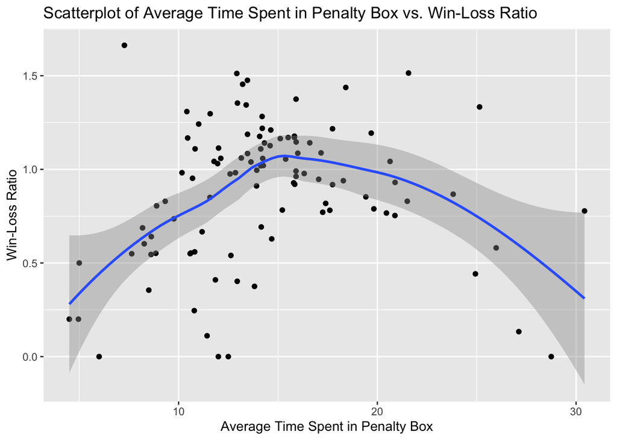

```r
ratiosScatter <- ggplot(team_totals_data, aes(x=penaltyGamesRatio, y=winLossRatio))
ratiosScatter +
  geom_point() +
  geom_smooth() +
  ggtitle("Scatterplot of Average Time Spent in Penalty Box vs. Win-Loss Ratio") +
  labs(x="Average Time Spent in Penalty Box", y="Win-Loss Ratio")
```

## Do Newer Teams Tend to be More Aggressive?

For this brief analysis, I filtered the dataset twice: once for years after or equal to 2000 (season stored as 20002001), then for years before 2000. I then took summary statistics for each of the ratios of Penalty to Games. In this case, we see that the median and mean for teams before 2000 is actually higher than that of teams that began in or after 2000, perhaps indicating that newer teams are actually less likely to be in the penalty box.

```r
post2000Penalties<- team_totals_data %>%
  filter(firstSeasonId >= 20002000) %>%
  select(teamName, penaltyGamesRatio, firstSeasonId) %>%
  arrange(desc(penaltyGamesRatio))
summary(post2000Penalties$penaltyGamesRatio)
```

```
##    Min. 1st Qu.  Median    Mean 3rd Qu.    Max.
##   7.272   8.894  10.581  10.339  11.010  13.222
```

```r
pre2000Penalties <- team_totals_data %>%
  filter(firstSeasonId < 20002000) %>%
  select(teamName, penaltyGamesRatio, firstSeasonId) %>%
  arrange(desc(penaltyGamesRatio))
summary(pre2000Penalties$penaltyGamesRatio)
```

```
##    Min. 1st Qu.  Median    Mean 3rd Qu.    Max.
##    4.50   11.91   14.20   14.83   17.11   30.43
```

## How are Weak Goalies Affecting a Teams’ Performances?

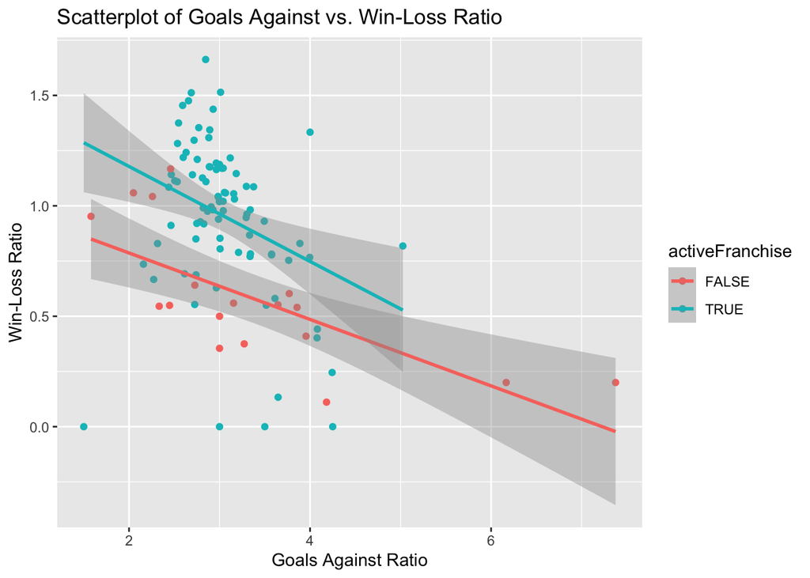

```r
team_totals_data$activeFranchise <- as.logical(team_totals_data$activeFranchise)
team_totals_data <- mutate(team_totals_data, goalsAgainstRatio = goalsAgainst / gamesPlayed)

goalsAgainstLossesPlot <- ggplot(team_totals_data, aes(x=goalsAgainstRatio, y=winLossRatio, color=activeFranchise))
goalsAgainstLossesPlot +
  geom_point() +
  geom_smooth(method=lm) +
  ggtitle("Scatterplot of Goals Against vs. Win-Loss Ratio") +
  labs(x="Goals Against Ratio", y="Win-Loss Ratio")
```